**Navn på gruppens medlemmer:** Espen Bjørge Urheim, Simen Nesland

*Levér en ferdig kjørt notebook som inkluderer alle resultater, helst eksportert som HTML-dokument. Det er tilstrekkelig at ett gruppemedlem leverer på vegne av alle i gruppa.*

# Om de numeriske øvingene i kvantemekanikk

Målet med de numeriske øvingene i kvantemekanikk er

- å bruke numeriske metoder og visualiseringer for å forstå kvantemekanikk bedre.
- å utvikle en generell "verktøykasse" du kan bruke også når du arbeider med andre øvinger og lærer nytt stoff i faget.
- å se ligningene i kvantemekanikken og løsninger av disse fra et generelt perspektiv.
- å utvikle ferdigheter innen programmering og numerikk.

Vi legger opp til bruk av Python sammen med bibliotekene `numpy`, `scipy` og `matplotlib` for numerikk, vitenskapelige beregninger og plotting. *Bruk disse for alt de er verdt!* God bruk av disse bibliotekene vil la deg uttrykke deg mer konsist enn om du kun bruker standard Python-funksjonalitet. Vi forventer at du selv finner fram til relevant funksjonalitet og dokumentasjon i bibliotekene. De er alle godt dokumentert på Internett.

Om du selv ønsker å benytte andre programmeringsspråk eller biblioteker, står du fritt til det. Noen oppgaver inkluderer en liten mengde hjelpekode i Python som du i så fall må omskrive på egen hånd, men de er ellers utformet uten tilknytning til et spesifikt språk. Vi forventer likevel at du leverer et alternativt, sammenhengende dokument med tekst, kode og resultater som svarer på oppgavene.

I Jupyter Notebook og Jupyter Lab er det mulig å bruke ulike *backends* for plotting med `matplotlib`. Dette er grovt forklart forskjellige underliggende "motorer" som bestemmer utseende og funksjonaliteten til figurene som produseres. Avhengig av hvilket av programmene du bruker, vil du erfare at en backend fungerer bedre enn andre. I Jupyter Notebook fungerer `notebook`-backenden best og uten behov for installasjon av ekstra programvare, men i Jupyter Lab må tillegget jupyter-matplotlib installeres for å få den optimale `widget`-backenden til å fungere. Begge programmene støtter også `inline`-backenden uten behov for tilleggsprogramvare, men denne produserer mindre fleksible figurer og bør kun brukes som reserveløsning. Prøv deg selv fram med backendene foreslått under for å finne den som fungerer best for deg.

```python
# uncomment ONE line to choose matplotlib backend
# if using Jupyter Notebook, use interactive "notebook" backend for best results
# if using Jupyter Lab, use interactive "widget" backend for best results
# if both fail, use static "inline" backend
%matplotlib notebook
#%matplotlib widget
#%matplotlib inline

import numpy as np
import matplotlib.pyplot as plt
from math import sqrt, sin, pi
import scipy.special
import scipy.linalg
import math
```

## Kort om fysiske enheter i numeriske beregninger

I numeriske beregninger må vi ta hensyn til den begrensede presisjonen og størrelsen til flyttallene som datamaskinen bruker for å representere relle tall. I kvantemekanikken møter vi spesielt ofte på Plancks reduserte konstant $\hbar \approx 6.63 \cdot 10^{-34} \text{ Js}$ og gjerne kvadratet $\hbar^2$. Det er i utgangspunktet ingenting i veien for å benytte SI-enheter for alle størrelser som opptrer i disse øvingene. Et alternativ er å benytte [atomære enheter](https://en.wikipedia.org/wiki/Hartree_atomic_units). Dette enhetssystemet er skreddersydd for beregninger på atomært nivå. Her er blant annet $\hbar$, elektronmassen $m_e$ og elementærladningen $e$ *definert* til å ha tallverdi $1$. For eksempel uttrykkes energier som multipler av én hartree, $E_h = \hbar^2 / m_e a_0^2 \approx 4.36 \cdot 10^{-18} \text{ J}$. En annen løsning er å benytte enheter som $\text{nm}$ og $\text{eV}$ for lengder og energier. En hartree tilsvarer ca. 27.2 eV, dvs. det dobbelte av grunntilstandsenergien i hydrogenatomet.

**Velg selv hensiktsmessige enheter til bruk i beregningene, men vær oppmerksom på den begrensede presisjonen til flyttall!**

```python
h_bar = 1   # 6.63*10**-34/2pi
m = 1       # 1.67*10**-27
e = 1       # 1.6*10**-19
dx = 0.1
```

# Numerisk løsning av den tidsuavhengige Schrödingerligningen

Å løse den tidsuavhengige Schrödingerligningen $$ \hat{H} \psi = -\frac{\hbar^2}{2 m} \psi'' + V \psi = E \psi, $$ dvs. å bestemme energiegenverdier $E$ og tilhørende energiegenfunksjoner $\psi(x)$ for et gitt potensial $V(x)$, er et sentralt problem i kvantemekanikken. Dette er ofte ingen enkel oppgave. Selv for potensialer som gir ligningen analytiske løsninger, kreves det ofte betydelig innsats og bruk av spesielle teknikker for å komme fram til disse. Vi skal her se på en elegant og generell teknikk for å løse ligningen numerisk for et vilkårlig potensial (i én dimensjon).

Numeriske løsningsmetoder innebærer alltid en viss avgrensning og diskretisering for å gjøre problemet endelig og håndterlig for en datamaskin. Vi avgrenser her delen av rommet vi ser på til å ligge mellom to endepunkter $x_0$ og $x_{N+1}$ og deler opp intervallet mellom dem i punktene $x_0, x_1, \ldots, x_N, x_{N+1}$ med lik avstand $\Delta x$ mellom hvert punkt. Utenfor dette området definerer vi potensialet til $V(x \leq x_0) = V(x \geq x_{N+1}) = \infty$, slik at $\psi(x \leq x_0) = \psi(x \geq x_{N+1}) = 0$ og det kun er bølgefunksjonens verdier på rutenettet $\boldsymbol{x} = [x_1, \ldots, x_N]^T$ som er ukjente og av interesse. Til hvert punkt tilordner vi verdiene $\psi_i = \psi(x_i)$ og $V_i = V(x_i)$ til energiegenfunksjonene og potensialet, og vi refererer til verdiene av funksjonene i alle punktene ved hjelp av vektorene $\boldsymbol{V} = [V_1, \ldots, V_N]^T$ og $\boldsymbol{\psi} = [\psi_1, \ldots, \psi_N]^T$.

En intuitiv og enkel tilnærming av den deriverte til en funksjon er den sentrale differansen $$ \psi'(x) = \frac{\psi(x + \Delta x / 2) - \psi(x - \Delta x / 2)}{\Delta x} $$ Om vi bruker denne tilnærmingen to ganger, kan vi også tilnærme den andrederiverte som $$ \psi''(x) = \frac{\psi'(x + \Delta x / 2) - \psi'(x - \Delta x / 2)}{\Delta x} = \frac{\psi(x + \Delta x) - 2 \psi(x) + \psi(x - \Delta x)}{\Delta x^2}$$

Ved å sette denne tilnærmingen inn i den tidsuavhengige Schrödingerligningen, kan vi tilnærme den numerisk som $$-\frac{\hbar^2}{2 m} \frac{\psi_{i+1} - 2 \psi_i + \psi_{i-1}}{{\Delta x}^2} + V_i \psi_i = E \psi_i \qquad \text{for}\,\, i = 1, 2, \ldots, N$$

Vi kan uttrykke denne ligningen på en elegant måte ved å innføre $N \times N$-Hamiltonmatrisen $H$ med elementer $$ H_{i j} = \begin{cases} \hbar^2 / (m \Delta x^2) + V_i & \text{for} \,\, i = j & \text{(på diagonalen)} \\ -\hbar^2 / (2 m \Delta x^2) & \text{for} \,\, i = j \pm 1 & \text{(på semidiagonalene)} \\ 0 & \text{ellers} \\ \end{cases} $$ og benytte oss av vektoren $\boldsymbol{\psi} = [\psi_1, \ldots, \psi_N]^T$. Den tar da formen $$ H \boldsymbol{\psi} = E \boldsymbol{\psi} $$ Energiene $E$ og energiegenfunksjonene $\boldsymbol{\psi}$ er dermed egenverdier og egenvektorer til matrisen $H$!

Numerikkbiblioteker har funksjonalitet for å finne egenverdier og egenvektorer til vilkårlige matriser. De har gjerne også spesialiserte funksjoner som gjør dette mer effektivt for matriser med en spesiell form, for eksempel som den *tridiagonale* (samt reelle og symmetriske) formen til matrisen $H$.

**Skriv en funksjon som beregner og returnerer alle energiegenverdier $E$ og tilhørende energiegenfunksjoner $\boldsymbol{\psi}$ for en partikkel med masse $m$ som befinner seg i et gitt potensial $\boldsymbol{V}$ på rutenettet $\boldsymbol{x}$. Normér energiegenfunksjonene i forstanden $\int |\psi|^2 \mathrm{d}x$ = 1.**

```python
N = 1000                 # Antall punkter langs x
b = 4                    # Bredde på brønn [nm]
deep = 2                 # Dybde på brønn [eV]
dist_fac = 0.0529        # Faktor strekning Hartree --> nm
e_fac = 1/27.2           # Faktor energi Hartre --> eV


def create_V(N,b,deep):
    """
    Lager potensial-array
    N: heltall. Antall punkter
    b: tall. Bredde på brønn
    deep: tall. Dybde på brønn
    """
    b = int(b/dist_fac)
    V = np.full(N, -deep)
    nulls = int((N-b)/2)
    V[:nulls + 1] = 0
    V[(nulls + b + 1):] = 0
    return V

def calc_E_psi(m, V):
    """
    Regner ut energiegenverdier og energiegenfunksjoner for gitt potensial
    m: tall. Masse til partikkel
    V: 1D-array med potensial-verdier
    """
    N = int(len(V))
    d = [h_bar**2/(m*dx**2) + V[i] for i in range(len(V))]
    semi_d = [-h_bar**2/(2*m*dx**2) for i in range(len(V)-1)]

    # Returnerer H sine egenverdier E og array med egenvektorer psi
    E,psi = scipy.linalg.eigh_tridiagonal(d,semi_d, select ="a")

    psi = np.transpose(psi)
    C = normalize(psi[0])
    psi *= C

    return E, psi

def normalize(psi_n):
    """
    Regner ut normaliserings-faktor for psi-funksjon
    psi_n: 1D-array med verdier for psi som skal normaliseres
    """
    summ = 0
    for value in psi_n:
        summ += value**2
    C = 1/summ
    return C
```

I resten av øvingen skal vi rett og slett bare bruke denne numeriske løsningsmetoden på en rekke forskjellige potensialer. I noen av eksemplene skal vi også sammenligne de numeriske verdiene med analytiske resultater. For å gjøre denne prosessen så enkel som mulig, foreslår vi at du her skriver én "ultimat" plottefunksjon som du kan gjenbruke i alle disse oppgavene.

**Skriv en funksjon som framstiller potensialet $\boldsymbol{V}$, energiegenverdier $E$ og energiegenfunksjoner $\boldsymbol{\psi}$ (eller absoluttkvadratene $|\boldsymbol{\psi}|^2$) på rutenettet $\boldsymbol{x}$ grafisk. Funksjonen skal også kunne brukes til å sammenligne to sett med (numeriske og analytiske) energier og energiegenfunksjoner.**

**Gjør gjerne dette parallelt med resten av oppgavene, slik at du kan tilpasse framstillingen basert på behovene som oppstår. Se gjerne i forelesningsnotater, bøker og søk rundt på Internett for å få litt inspirasjon til hvordan framstillingen kan gjøres.**

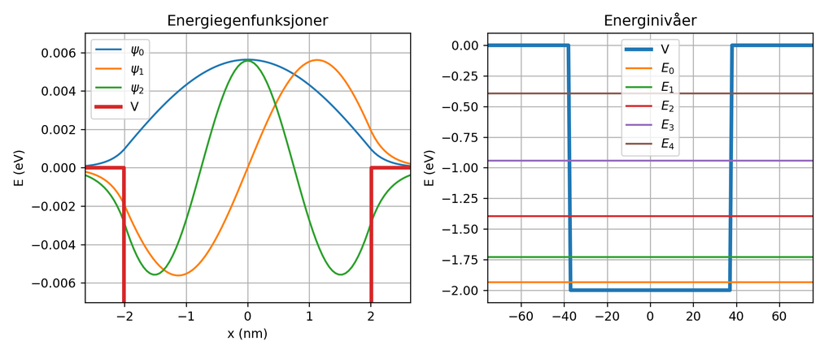

```python
def psi_plot(V, psi, psi_max, b, well = True, anal = False):
    """
    Plotter energi-egenfunskjoner
    V: 1D-array med potensial-verdier
    psi: 2D-array med energi-egenfunskjoner
    psi_max: heltall. Plotter funksjoner opp til gitt verdi
    b: bredde på brønn
    well: bool. Bestemmer om brønnen skal plottes
    """
    b = int(b/dist_fac)
    psi_top = max(psi[1])*e_fac
    x0 = list(V).index(V[len(V)//2])
    x = np.arange(-int(N/2),int(N/2))
    plt.xlabel("x (nm)")
    plt.ylabel("E (eV)")
    plt.title("Energiegenfunksjoner")
    plt.grid()
    leg_list = []
    for i in range(psi_max):
        plt.plot(x*dist_fac,psi[i]*e_fac)
        leg_list.append(f"$\psi_{i}$")
    plt.legend(leg_list)
    if anal:
        plt.xlim([0,b*dist_fac])
    else:
        plt.xlim([(-b/1.5)*dist_fac,(b/1.5)*dist_fac])
    if well:
        plt.plot(x*dist_fac,V, linewidth = 3) # brønn
        leg_list.append("V")
    plt.legend(leg_list)
    plt.ylim([-psi_top-psi_top/4,psi_top+psi_top/4])

def energy_plot(E, E_max, well = True):
    """
    Plotter energi-verdier
    E: 1D-array med energi-verdier
    E_max: heltall. Plotter verdier opp til gitt verdi
    well: bool. Bestemmer om brønnen skal plottes
    """
    x = np.arange(-int(N/2),int(N/2))
    plt.ylabel("E (eV)")
    plt.title("Energinivåer")
    plt.grid()
    leg_list = []
    if well:
        plt.plot(x,V, linewidth = 3)
        leg_list.append("V")
    for i in range(E_max):
        E_i = np.full(N,E[i])
        plt.plot(x,E_i)
        leg_list.append(f"$E_{i}$")
    plt.xlim([-b/dist_fac,b/dist_fac])
    plt.legend(leg_list)



N = 1000                 # Antall punkter langs x
b = 4                    # Bredde på brønn [nm]
deep = 2                 # Dybde på brønn [eV]

V = create_V(N,b,deep)
E,psi = calc_E_psi(m,V)

# PLOTTER
fig = plt.figure(figsize=(9.4,4))
plt.subplot(1,2,1)
psi_plot(V,psi,3,b)

plt.subplot(1,2,2)
energy_plot(E, 5, True)
fig.tight_layout()
```

## Partikkel i boks

Et av de første kvantemekaniske problemene vi støter på er partikkel i boks. Her er potensialet, de normerte energiegenfunksjonene og energiegenverdiene $$ V(x) = \begin{cases}0 & \text{for}\,\, 0 \leq x \leq L \\ \infty & \text{ellers} \end{cases}, \quad \psi(x) = \sqrt{\frac{2}{L}} \sin{\frac{n \pi x}{L}}, \quad E = \frac{n^2 \pi^2 \hbar^2}{2 m L^2}, \quad \quad n = 1, 2, \ldots, $$

**Sammenlign numeriske og analytiske verdier for noen energier og energiegenfunksjoner for et elektron i en boks grafisk.**

**Hvordan er spredningen i energinivåene?**

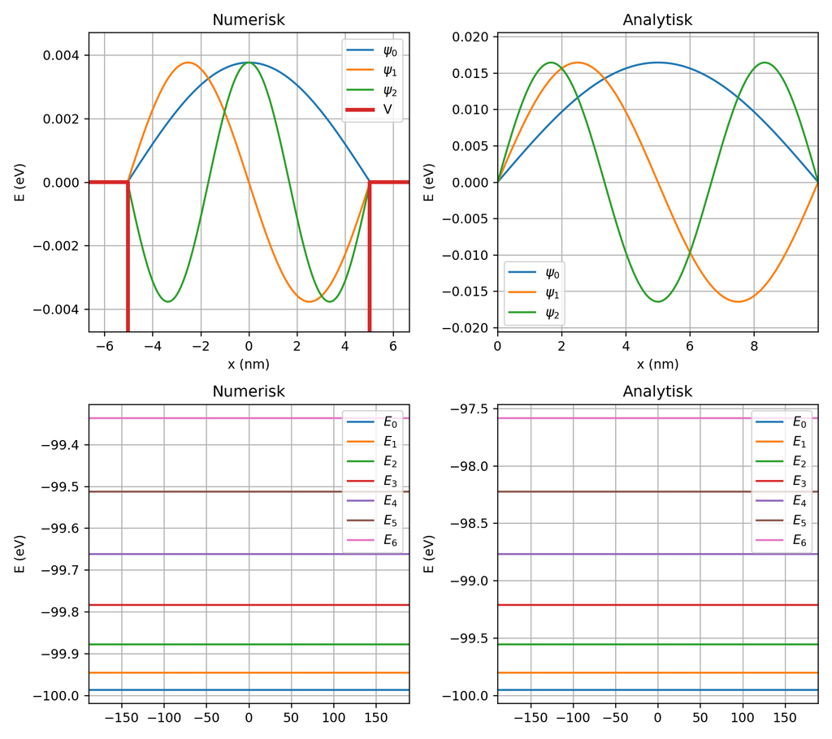

```python
def pib_anal(n_f,b,xs):
    """
    Regner ut analytiske energiegenfunskjoner og verdier for partikkel i boks
    n_f: heltall. Regner ut for verdier n_f-1 funksjoner
    b: tall. Bredde på brønn
    xs: 1D-array med x-verdier
    """
    psi_anals = []
    E_anals = []
    ns = np.arange(1,n_f+1)
    for n in ns:
        psi_anal = []
        for x in xs:
            psi_anal.append(sqrt(2/b)*sin(n*pi*x*dist_fac*(1/b)))
        psi_anals.append(psi_anal)
        E_anals.append((1/2*m)*(n*pi*h_bar*(1/b))**2)
    return E_anals, np.array(psi_anals)


deep = 1e2                           # dybde på brønn
b = 10                               # bredde på brønn
N = 1000                             # antall punkter
n_max_psi = 3                        # siste tilstand som plottes for psi
n_max_E = 7                          # siste tilstand som plottes for E


x = np.arange(-N/2,N/2)
V = create_V(N,b,deep)
E, psi = calc_E_psi(m, V)
E_anals, psi_anals = pib_anal(max([n_max_psi, n_max_E]) + 1,b,x)
E_anals = np.array(E_anals)-deep


# PLOTTER
fig = plt.figure(figsize=(9,8))

plt.subplot(2,2,1)
psi_plot(V,psi,n_max_psi,b)
plt.title("Numerisk")

plt.subplot(2,2,2)
psi_plot(V,psi_anals,n_max_psi,b, False, True)
plt.title("Analytisk")

plt.subplot(2,2,3)
energy_plot(E, n_max_E, False)
plt.title("Numerisk")

plt.subplot(2,2,4)
energy_plot(E_anals, n_max_E, False)
plt.title("Analytisk")

fig.tight_layout()
plt.show()
```

### ------------------------------------------------------------------------------------------

## Harmonisk oscillator

Et annet standard kvantemekanisk problem er den harmoniske oscillatoren med $$ V(x) = \frac{1}{2}m \omega^2 x^2, \quad \psi(x) = \frac{1}{\sqrt{2^n n!}} \cdot \left(\frac{m \omega}{\pi \hbar}\right)^{1/4} \cdot \exp{\left(-\frac{m \omega x^2}{2 \hbar}\right)} \cdot H_n\left(\sqrt{\frac{m \omega}{\hbar}}x\right), \quad E = \left(n+\frac{1}{2}\right)\hbar \omega, \quad \quad n = 0, 1, 2, \ldots $$ Funksjonene $H_n(y)$ (med dimensjonsløs $y$) kalles [(fysikerens) Hermitepolynomer](https://en.wikipedia.org/wiki/Hermite_polynomials). De er tilgjengelige i numerikkbiblioteker, men kan også beregnes fra rekursjonsrelasjonen $$ H_n(x) = 2 x H_{n-1}(x) - 2 (n-1) H_{n-2}(x), \quad H_0(x) = 1, \quad H_1(x) = 2 x$$

Den harmoniske oscillatoren er spesielt interessant i topartikkelsystemer, der et problem med for eksempel to atomer med masse $m_1$ og $m_2$ i et toatomig molekyl reduseres til et ekvivalent enpartikkelproblem med *redusert masse* $m = m_1 m_2 / (m_1 + m_2)$. Sammen med konstanten $\omega$ utgjør denne et mål på en fjærkonstant som beskriver vibrasjonsbevegelsen mellom de to atomene.

**Sammenlign numeriske og analytiske verdier for noen energier og energiegenfunksjoner i en harmonisk oscillator grafisk.**

**Hvordan er spredningen i energinivåene?**

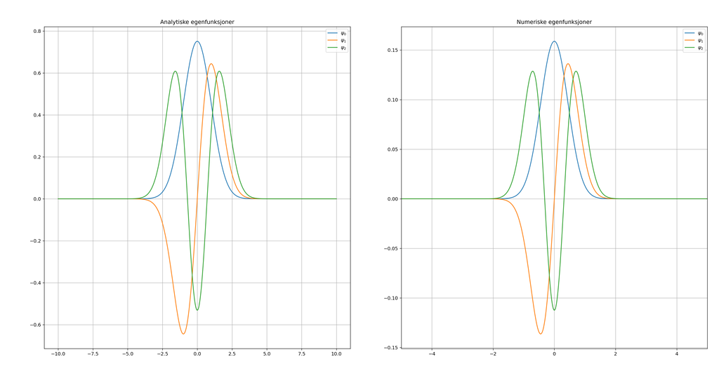

```python
omega = 1          # Vinkelfrekvens
n = 1000           # Antall punkter

def V_osc(x):
    """
    Regner ut potensial for harmonisk oscillator
    x: 1D-array med x-verdier
    """
    return 0.5*m*omega**2*x**2

def psi_osc(x,n):
    """
    Regner ut energiegenfunksjoner for harmonisk oscillator, analytisk.
    x: 1D-array med x-verdier
    n: heltall. Finner energiegenfunk. for n'te tilstand
    """
    psi = np.zeros(len(x))
    for xn in range(len(x)):
        faktor1 = 1/(sqrt(2**(n)*math.factorial(n)))
        faktor2 = (m*omega/(np.pi*h_bar))**(1/4)
        faktor3 = math.exp(-m*omega*x[xn]**2/(2*h_bar))
        faktor4 = scipy.special.eval_hermite(n,x[xn]*sqrt(m*omega/h_bar)) # scipy-funksjon for å regne ut H_n
        psi[xn] = faktor1 * faktor2 * faktor3 * faktor4
    return psi

def E_osc(N):
    """
    Regner ut energiegenverdier for harmonisk oscillator, analytisk.
    N: heltall. Antall punkter
    """
    E = np.zeros(N)
    for n in range(N):
        E[n] = (n+1/2)*h_bar*omega
    return E

N = 1000
x = np.linspace(-10,10,1000)
V = V_osc(x)
E, psi = calc_E_psi(m, V)

# PLOTTER ANALYTISKE OG NUMERISKE VERDIER FOR PSI OG E
fig1 = plt.figure(figsize=(9.5,5))

# Analytisk psi
plt.subplot(1,2,1)
plt.title("Analytiske egenfunksjoner")
plt.grid()
leg_list = []
for i in range(3):
    plt.plot(x, psi_osc(x,i))
    leg_list.append(f"$\psi_{i}$")
plt.legend(leg_list)


# Numerisk psi
plt.subplot(1,2,2)
plt.title("Numeriske egenfunksjoner")
plt.grid()
leg_list = []
for i in range(3):
    plt.plot(x, psi[i])
    leg_list.append(f"$\psi_{i}$")
plt.xlim(-5,5)
plt.legend(leg_list)
fig1.tight_layout()
```

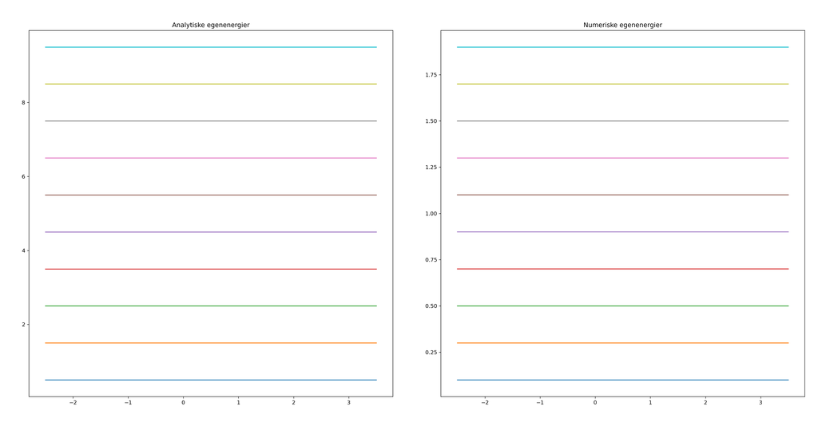

```python
fig2 = plt.figure(figsize=(9.5,5))

# Analytisk E
plt.subplot(1,2,1)
plt.title("Analytiske egenenergier")
for i in range(10):
    plt.plot(x, np.full(len(x),E_osc(N)[i]))

# Numerisk E
plt.subplot(1,2,2)
plt.title("Numeriske egenenergier")
for i in range(10):
    plt.plot(x,np.full(len(x), E[i]))


plt.show()
fig2.tight_layout()
```

## Kommentar

### ------------------------------------------------------------------------------------------

## Partikkel i endelige brønnpotensialer

Et tredje velkjent eksempel er enkeltbrønnen $$V(x) = \begin{cases} -V_0 & \text{for}\,\, 0 < x < w \\ 0 & \text{ellers} \end{cases}$$ med bredde $w$ og brønndybde $V_0 > 0$. I dette potensialet finnes ingen analytiske løsninger for de bundne stasjonære tilstandenes energiegenverdier.

Enkeltbrønnen kan generaliseres til et potensial bestående av $N_w$ slike enkeltbrønner plassert ved siden av hverandre med en fast avstand $g$ mellom hver brønn. Med første brønn i $x = 0$, kan vi uttrykke det sammensatte brønnpotensialet stykkevis som

$$V(x) = \begin{cases} 0 & \text{for}\,\, x < 0 \,\, \text{og} \,\, x > N_w (w + g) & \text{(utenfor brønnområdet)} \\ -V_0 & \text{for}\,\, \frac{x}{w+g} - \left\lfloor \frac{x}{w+g} \right\rfloor < \frac{w}{w+g} & \text{(i brønnene)} \\ 0 & \text{ellers} & \text{(mellom brønnene)} \\ \end{cases}$$

Dette er en enkel modell for det periodiske potensialet som et elektron opplever i et fast stoff med en regulær krystallinsk struktur, for eksempel et metall.

**Framstill de bundne tilstandene for et elektron både i en enkeltbrønn og i et sammensatt potensial bestående av mange brønner grafisk. Legg inn et passe stort område med $V = 0$ på begge sider av brønnområdet.**

**Hvordan distribueres energinivåene i potensialet bestående av mange brønner sammenlignet med enkeltbrønnen? Kan du ut fra dette forklare hva vi mener med *energibåndstrukturen* til et fast stoff ved hjelp av begrepene *båndbredde* og *båndgap*?**

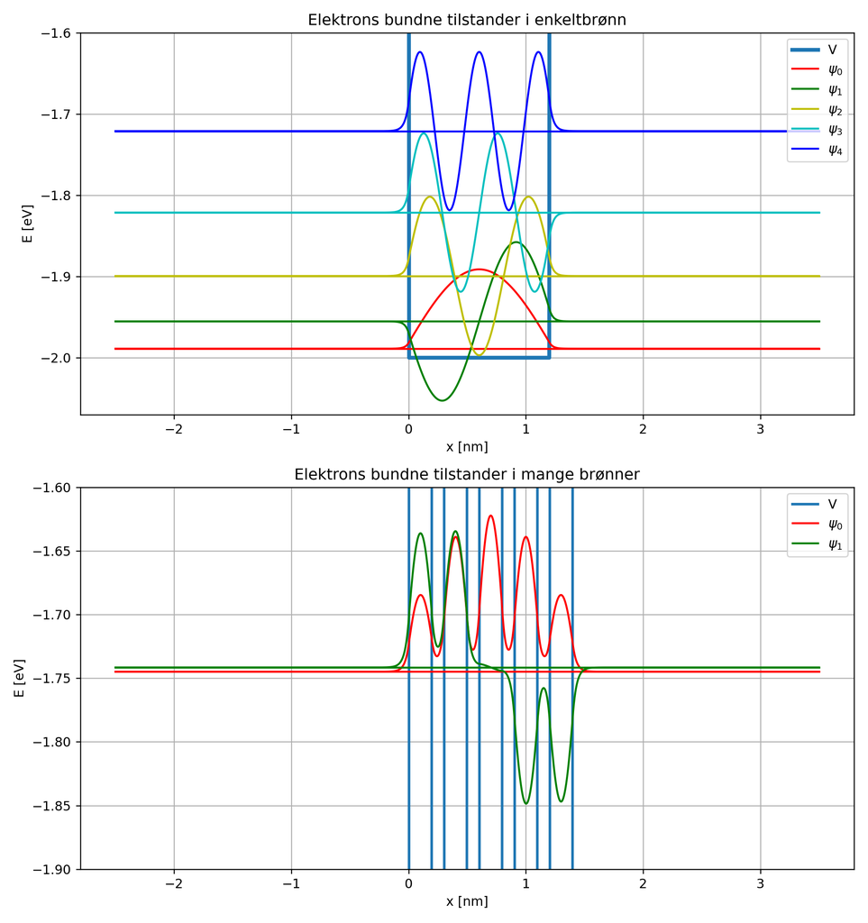

```python
w = 1.2                # bredde på brønn
g = 0.1                # avstand mellom hver brønn
V0 = 2                 # dybde/høyde på brønn
N_w = 5                # antall brønner
n_sammensatt = [0,1]   # hvilke tilstander som skal plottes for sammensatt

def V_enkelt(x):
    """
    Lager potensial-array for enkeltbrønn
    x: 1D-array med x-verdier
    """
    V = []
    for i in range(len(x)):
        if 0 < x[i] < w:
            V.append(-V0)
        else:
            V.append(0)
    return V

def V_sammensatt(x):
    """
    Lager potensial-array for sammensatte brønner
    x: 1D-array med x-verdier
    """
    V = []
    for i in range(len(x)):
        if x[i] > N_w*(w+g) or x[i] < 0:
            V.append(0)
        elif x[i]/(w+g) - np.floor(x[i]/(w+g)) < w/(w+g):
            V.append(-V0)
        else:
            V.append(0)
    return V

E_enkelt, psi_enkelt = calc_E_psi(m, V_enkelt(x))
fig1 = plt.figure(figsize=(9.4,10))
x = np.linspace(-2.5,3.5, 1000)

# Enkeltbrønn:
plt.subplot(2,1,1)
plt.title("Elektrons bundne tilstander i enkeltbrønn")
plt.grid()
V_p, = plt.plot(x, V_enkelt(x), linewidth = 3)
leg_list = ["V"]
leg_things = [V_p]
color_list = ["r", "g", "y", "c", "b"]
for i in range(5):
    psi_p, = plt.plot(x, psi_enkelt[i]+np.full(len(x),E_enkelt[i]), color = color_list[i])
    plt.plot(x, np.full(len(x),E_enkelt[i]), color = color_list[i])
    leg_list.append(f"$\psi_{i}$")
    leg_things.append(psi_p)
plt.ylabel("E [eV]")
plt.xlabel("x [nm]")
plt.legend(leg_things,leg_list)
plt.show()
plt.ylim([-V0-0.07,-V0+0.4])


# Sammensatte brønner
w = 1/(N_w)
E_sammensatt, psi_sammensatt = calc_E_psi(m, V_sammensatt(x))

plt.subplot(2,1,2)
V_p, = plt.plot(x, V_sammensatt(x), linewidth = 2)
plt.grid()
plt.title("Elektrons bundne tilstander i mange brønner")
leg_list = ["V"]
leg_things = [V_p]
for i in range(n_sammensatt[0],n_sammensatt[-1]+1):
    psi_p, = plt.plot(x, psi_sammensatt[i]+np.full(len(x),E_sammensatt[i]),color = color_list[i])
    plt.plot(x, np.full(len(x), E_sammensatt[i]), color = color_list[i])
    leg_list.append(f"$\psi_{i}$")
    leg_things.append(psi_p)
plt.ylabel("E [eV]")
plt.xlabel("x [nm]")
plt.legend(leg_things, leg_list)
plt.ylim([-1.9,-1.6])

fig1.tight_layout()
```

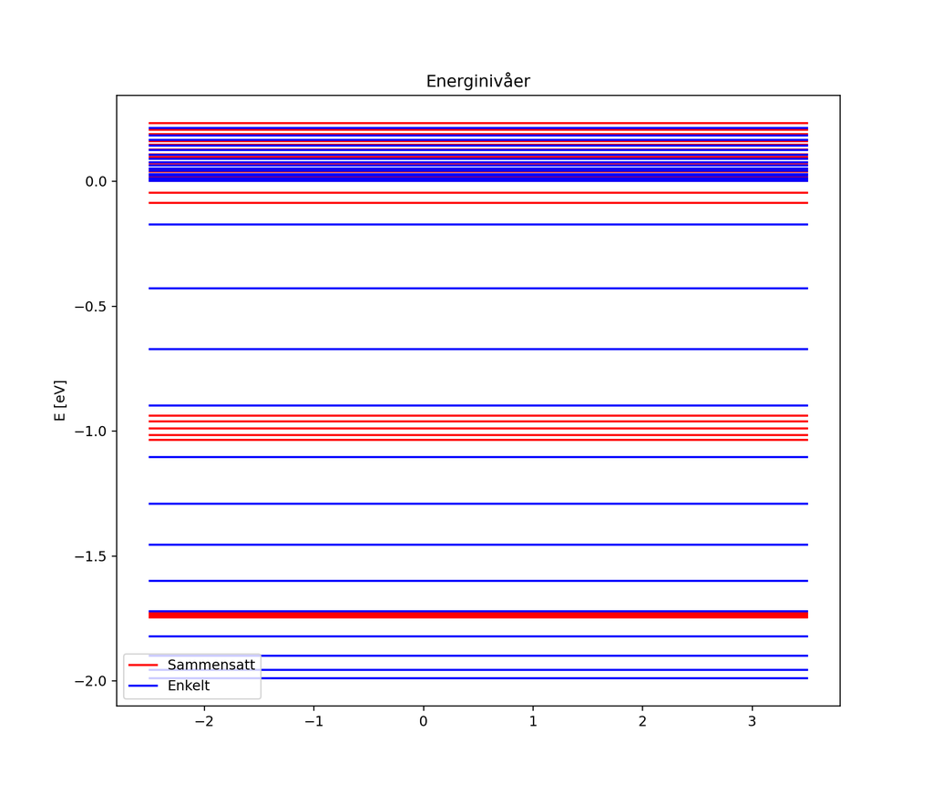

```python
# Energinivåer
fig2 = plt.figure(figsize=(9.4,8))
for i in range(30):
    Ep, = plt.plot(x, np.full(len(x), E_sammensatt[i]),"r")
    Ep2, =plt.plot(x, np.full(len(x), E_enkelt[i]),"b")
plt.legend(["Sammensatt", "Enkelt"])
plt.title("Energinivåer")
plt.ylabel("E [eV]")
plt.show()
```

## Kommentar

Vi ser at for enkelt-brønnen blir energinivåene spredt slik som vi kjenner. Tettere i bunnen, også mer og mer spredt oppover, og et tilnærmet kontinuerlig bånd over. For de sammensatte brønnene får vi "bursts" med energinivåer, nesten tilsvarende korte bånd. Det er like mange nivåer som brønner for hver "burst". Dette er slik vi kjenner igjen fra strukturen i faste stoffer, som kan tilnærmes med denne sammensatte brønner-strukturen i én dimensjon. Båndgapet er differansen mellom toppen av valensbåndet (øverste bånd som er fylt) og ledningsbåndet (nederste bånd som ikke er fylt).

### ------------------------------------------------------------------------------------------